# Analysis of hunting effects on spatial structure of trees with different dispersers

Model fitting

Robert Bagchi

13 October, 2017

## 1. Preliminaries

### 1.1 Loading and installing libraries

If you need to install the `ReplicatedPointPatterns` package, you can execute the following code. Note, you need the `devtools` package installed. To excute the code below, set ‘eval=TRUE’ ’

```r
##devtools::install_github('robertbagchi/ReplicatedPointPatterns')
##devtools::install_github('BagchiLab/RSPPlme4')
```

We can then load all the necessary libraries.

```r
rm(list=ls())
# data organisation
library(abind)
library(reshape)
library(tidyr)
library(dplyr)
library(broom)

## spatial analysis
library(spatstat)
##library(ReplicatedPointPatterns)
library(RSPPlme4)

## plotting
library(ggplot2)
library(cowplot)
library(grid)
library(gtable)
library(ggrepel)
library(ggthemes)
library(RColorBrewer)
library(viridis)
```

### 1.2 Define some useful functions for this analysis

- Function that standardises a vector (standardise)
- Function to convert K functions to L functions (K2L)
- Function that takes the output from the model and puts it in a convenient format for plotting (kfunclme2plot)
- Function that plots the BLUEs against distance (plot.kfunctionlme)
- Function that plots the coefficient and confidence intervals from a bootstrap (effectplot.Kfunctionlme)
- Function to extract random effect BLUPs to allow plotting (extractModRanefs)
- Function to extract residuals and covariates for plotting (plotModResids)

```r
##source("PeruConvenienceFunctions.R")
source("../PeruAnalysis/PeruConvenienceFunctions_klmer.R")
```

### 1.3 ggplot theme for paper

```r
theme_cust <- theme(axis.text = element_text(size=7),
                    axis.title.y=element_text(size=10),
                    plot.margin=unit(c(0.5, 0.3, 0.5, 0 ),  'lines'),
                    strip.text=element_text(size=8),
                    strip.text.y=element_text(angle=0),
                    strip.background =element_rect(fill="white", colour="NA"),
                    panel.grid.major=element_blank(),
                    panel.grid.minor=element_blank(),
                    legend.text=element_text(size=8),
                    legend.title=element_text(size=10))
```

### 1.4 Load the pre-pr ocessed data

We load the data that have been processed in another script. These same data can also be used on the cluster for more extensive simulations.

```r
load(file='../data/data4peruanalysis_v8.3_2class.RData')

## remove species with unknown or abiotic dispersal
hyperdat.bi.sel.c <- subset(hyperdat.bi.sel, Unkwn !=1 & Abiotic !=1) ## Bivariate
hyperdat.uni.sel.c <- subset(hyperdat.uni.sel, Unkwn !=1 & Abiotic !=1) ## Univariate
```

Set number of iterations for bootstrapping - keep small for trials (takes a long time). The code was run on a HPC for paper

```r
nsim <- 999
rmax ## double check  value set in previous code
```

```
## [1] 15
```

```r
dbhlabs <- c("<1", "1-2", "1-4")[1:(length(sizeclasses)-1)]
distlist <- list(1:15, 1:5, 6:10, 11:15) ## distances to test hypotheses at
```

## 2 Sapling only analysis (for hypothesis 1)

### 2.1 Subset the data

The first part of the analysis only uses the sapling data because the first hypothesis (hunting should increase clustering of large-vertebrate species) should be more apparent in saplings. We first subset the data, and then fit the models. The first model (univariate) looks at sapling neighbours around saplings, the second (bivariate) looks at adult neighbours around saplings.

```r
## First sapling only models
hyperdat.uni.sap <- subset(hyperdat.uni.sel.c, stage=='dbh_0')
hyperdat.bi.sap <- subset(hyperdat.bi.sel.c, stage=='dbh_0')

## Then juvenile-only models
hyperdat.uni.juv <- subset(hyperdat.uni.sel.c, stage=='dbh_1')
hyperdat.bi.juv <- subset(hyperdat.bi.sel.c, stage=='dbh_1')
```

```r
hyperdat.uni.sap.c <- hyperdat.uni.sap

hyperdat.uni.sap.c <- subset(hyperdat.uni.sap,
                           !(pname=="BM" & sp.id %in% c(585, 307, 562, 562, 736) |
                               pname == "CC1" & sp.id %in% c(559) |
                               pname=="LA" & sp.id %in% c(561, 749, 764) |
                               pname=="RA" & sp.id %in% c(426, 446) |
                               pname=="TRC" & sp.id %in% c(609, 411, 562)
                           )
)

hyperdat.bi.sap.c <- hyperdat.bi.sap
hyperdat.bi.sap.c <- subset(hyperdat.bi.sap,
                            !(pname=="BM" & sp.id %in% c(491, 562) |
                                pname=="CC2" & sp.id %in% c(370, 563) |
                                pname == "LA" & sp.id %in% c(735, 379) |
                                pname == "RA" & sp.id %in% c(552, 293) |
                                pname == "TRC" & sp.id %in% c(472))
)
```

### 2.2 Univariate sapling-only models

#### 2.2.1 Fit model

We start off with an analysis of recruit-recruit spatail structure

We first fit the model.

```r
## fit the model
sapMod.uni <- klmerHyper(K~huntpres*HSD + (1|site),  hyper= hyperdat.uni.sap.c,
                weights=wts, r= 0:rmax, correction="border")
print(sapMod.uni)
```

```
## linear mixed model fitted to k function
## distances modelled:
##  15 distances
##  range = 1 15
## Fixed effects
##                  1     2     3     4     5      6     7      8       9       10
## (Intercept)  14.28 29.72 46.40 58.03 73.77  87.29  95.3 101.94 113.151 111.3885
## huntpres     -1.28 -2.89 -4.75 -7.38 -9.11  -9.62 -10.3  -6.83  -0.956  -0.0221
## HSD          -1.78 12.25 32.59 65.11 84.93 116.20 144.1 170.66 190.369 209.3964
## huntpres:HSD  3.14  7.36 11.96 23.54 28.29  39.23  44.7  40.97  39.129  40.5532
##                  11     12     13     14     15
## (Intercept)  122.87 131.44 132.97 129.11 126.88
## huntpres       5.82   1.28   3.01   2.71   5.18
## HSD          208.72 229.01 236.93 258.86 269.62
## huntpres:HSD  33.22  49.41  44.75  47.94  49.76
```

```r
## fit the model
juvMod.uni <- klmerHyper(K~huntpres*HSD + (1|site),  hyper= hyperdat.uni.juv,
                weights=wts, r= 0:rmax, correction="border")
print(juvMod.uni)
```

```
## linear mixed model fitted to k function
## distances modelled:
##  15 distances
##  range = 1 15
## Fixed effects
##                   1     2     3     4     5     6      7      8      9     10
## (Intercept)  10.938 27.35 38.07 51.06 60.12 73.38  81.89  86.21  96.32 108.18
## huntpres     -1.568 -2.39 -3.46 -5.52 -7.01 -6.62  -8.48  -4.49  -1.73   4.58
## HSD          -1.968  6.98 32.89 55.95 76.99 91.75 119.79 148.12 159.57 174.55
## huntpres:HSD  0.912  3.78  9.73 14.85 27.75 32.52  39.42  39.82  41.29  36.36
##                  11     12     13     14     15
## (Intercept)  107.58 113.03 118.66 110.35 118.92
## huntpres       3.65   5.26   4.78   3.68   6.11
## HSD          182.47 209.08 207.89 209.24 206.93
## huntpres:HSD  29.14  37.53  43.59  46.40  47.65
```

#### 2.2.2 Model diagnostics

Then we can look at some of the diagnostics using the functions defined in the sourced file, “PeruConvenienceFunctions.R”.

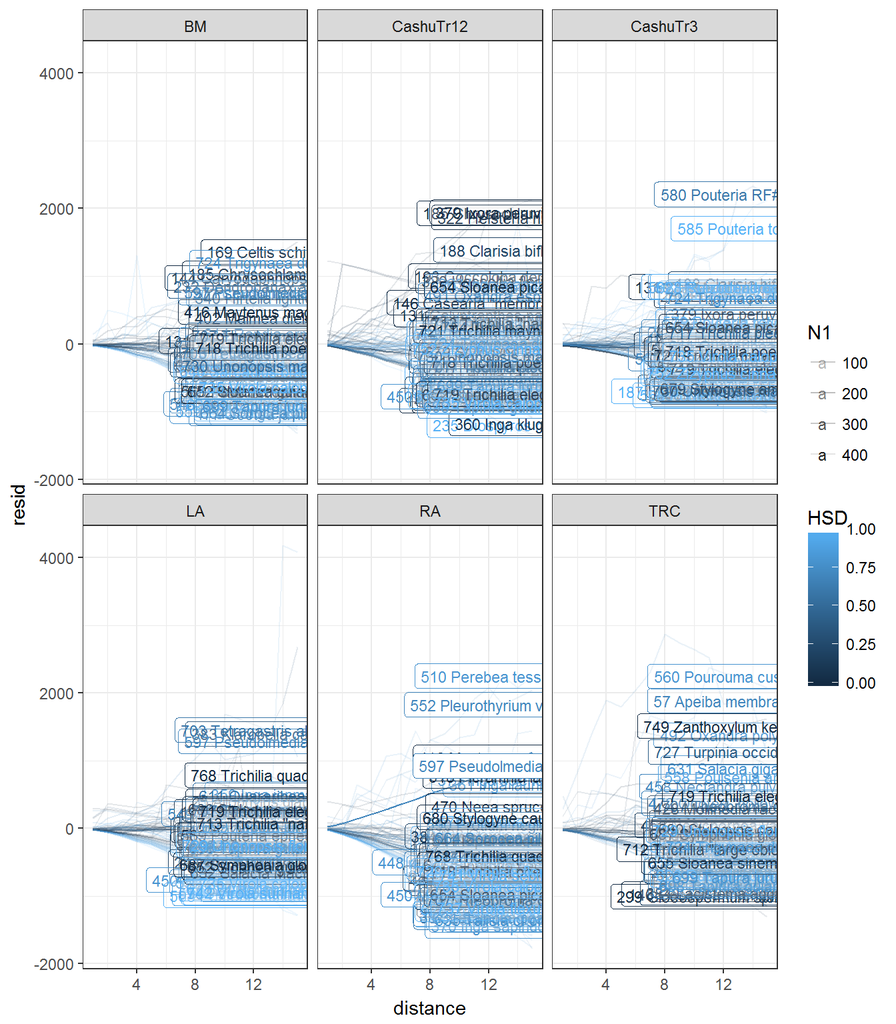

```r
## Residuals
resids.uni <- extractModResids(sapMod.uni)

## add data on species names
resids.uni$species <- rep(hyperdat.uni.sap.c$Spp,length(sapMod.uni))
resids.uni$sp.id <- rep(hyperdat.uni.sap.c$sp.id, length(sapMod.uni))
resids.uni$N1 <- rep(hyperdat.uni.sap.c$N1, length(sapMod.uni))

## residual K-functions - with species labels to idenify outliers
ggplot(data=resids.uni, aes(x=distance, y=resid, colour=HSD, alpha=N1, group=species)) +
  geom_line() +
  geom_label(data=subset(resids.uni, distance ==13),
             aes(label=paste(sp.id, species), x=distance, y=resid),
             size=3) +
  facet_wrap(~site) +
  theme_bw()
```

These species are generally relatively rare at the sites where they are outliers (see the N1 column), so probably have little effect on the analyisis.

#### 2.2.3 Calculate confidence intervals

```r
## First make the model matrix
preddat.sap <-  expand.grid(stage=c('S'),
                            huntpres= round(quantile(sitedat$huntpres, seq(0, 1, 0.25)), 1),
                            HSD = seq(0, 1, 0.25))

sapform <- update(formula(sapMod.uni[[1]], fixed.only=T), NULL~.) ## extract formula (and remove lhs)
modmat.sap <-  model.matrix(sapform, data=preddat.sap) ## make model matrix

sapMod.uni_ci <- confint(sapMod.uni, lin_comb=modmat.sap, nboot=nsim,
                         level=0.95, ncore=7, iseed=1234)
```

```
## clusters closed on exit
```

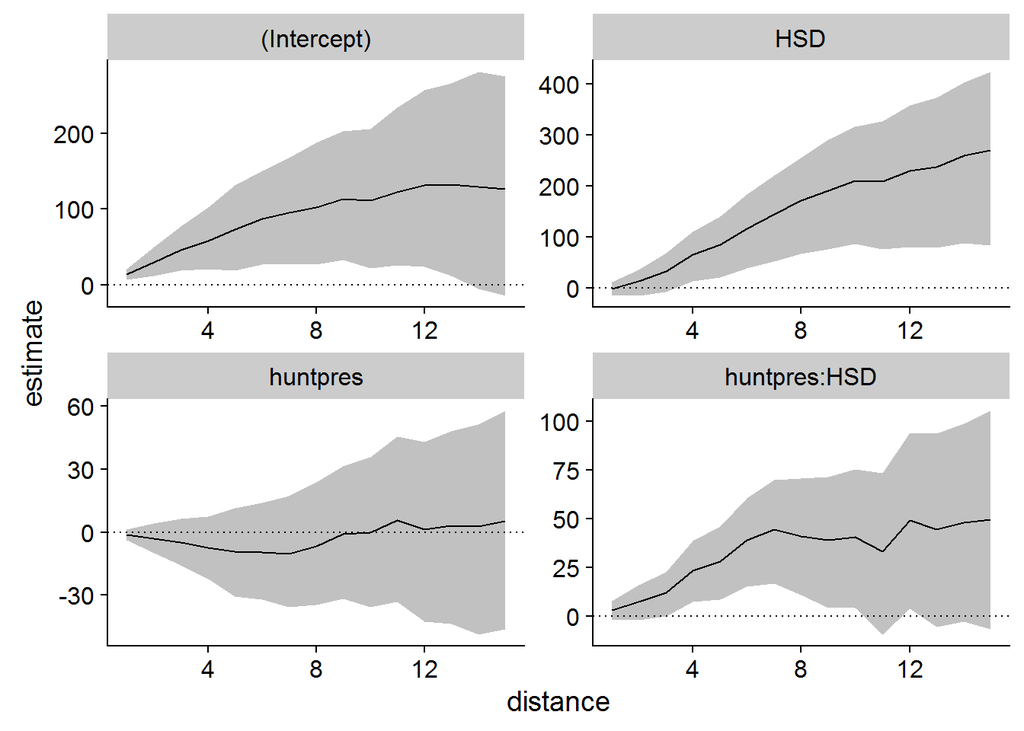

```r
plot(sapMod.uni_ci)
```

```r
save(sapMod.uni_ci, file="../results/v8.0/sapModuni.RData")
##load("../results/v8.0/sapModuni.RData")
```

### 2.3 Bivariate sapling only models

Next we analyse the adult-recruit distances.

#### 2.3.1 Model fitting

Once again, we first have to fit the model.

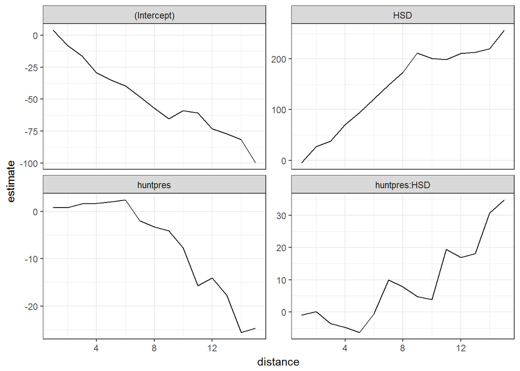

```r
## fit the model
sapMod.bi <- klmerHyper(K~huntpres*HSD + (1|site), hyper=hyperdat.bi.sap.c,
                        weights=wts, r=0:rmax, correction="border")
plot(sapMod.bi)
```

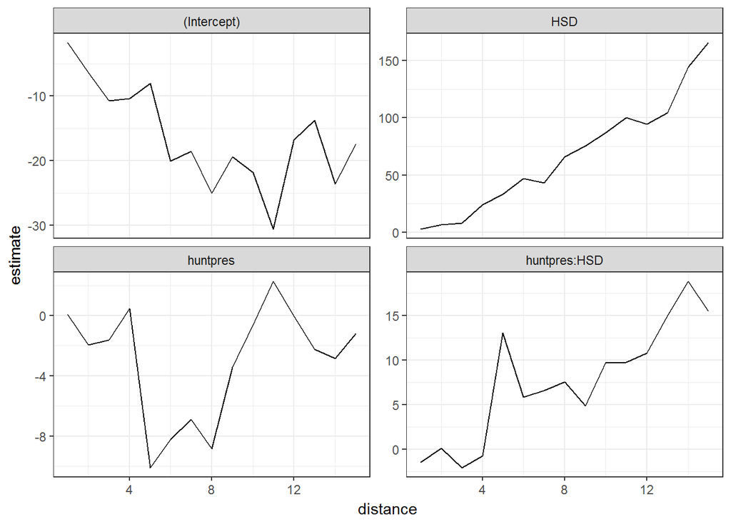

```r
## fit the model
juvMod.bi <- klmerHyper(K~huntpres*HSD + (1|site), hyper=hyperdat.bi.juv,
                        weights=wts, r=0:rmax, correction="border")
plot(juvMod.bi)
```

#### 2.3.2 model diagnostics

Then we can look at some of the diagnostics.

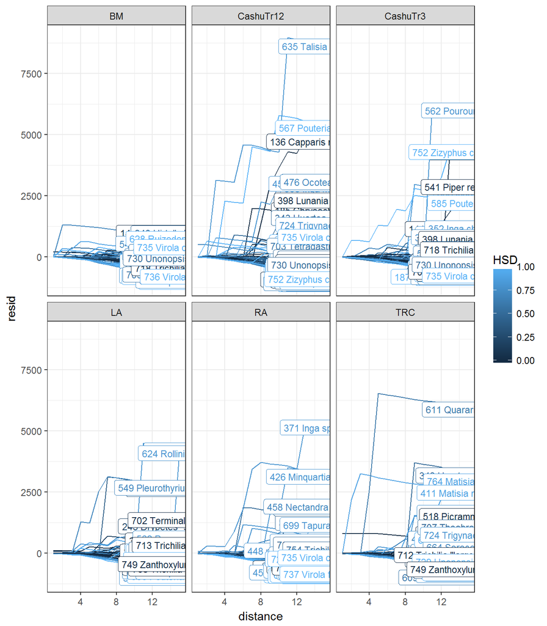

```r
resids.bi <- extractModResids(sapMod.bi)
## add data on species names
resids.bi$species <- rep(hyperdat.bi.sap.c$Spp, 15)
resids.bi$sp.id <- rep(hyperdat.bi.sap.c$sp.id, 15)
resids.bi$N <- rep(sqrt(hyperdat.bi.sap.c$N1*hyperdat.bi.sap.c$N2), 15)

## plotting the residuals with labels to identify the outliers.
ggplot(data=resids.bi, aes(x=distance, y=resid, colour=HSD, group=species)) +
  geom_line() +
  geom_label(data=subset(resids.bi, distance ==15),
             aes(label=paste(sp.id, species), x=distance, y=resid), size=3) +
  facet_wrap(~site) +
   theme_bw()
```

#### 2.3.3 Estimating the confidence intervals

```r
## Can use the model matrix from the univariate analysis
## Bootstrapping
sapMod.bi_ci <-  confint(sapMod.bi, lin_comb=modmat.sap, nboot=nsim,
                                       level=0.95, ncore=7, iseed=1234)
```

```
## clusters closed on exit
```

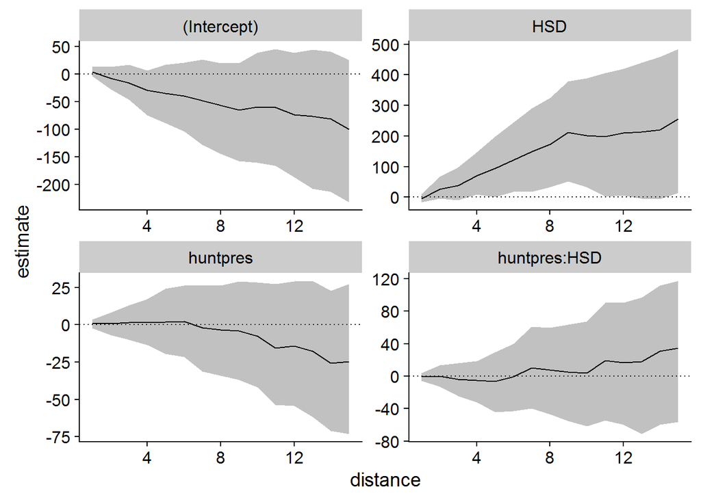

```r
plot(sapMod.bi_ci)
```

```r
save(sapMod.bi_ci, file= "../results/v8.0/sapModbi.RData")
##load("../results/v8.0/sapModbi.RData")
```

### 2.5 Examining coefficients of models

We can plot the coefficients from the models and their confidence intervals using functions defined in the convenience functions code side by side with.

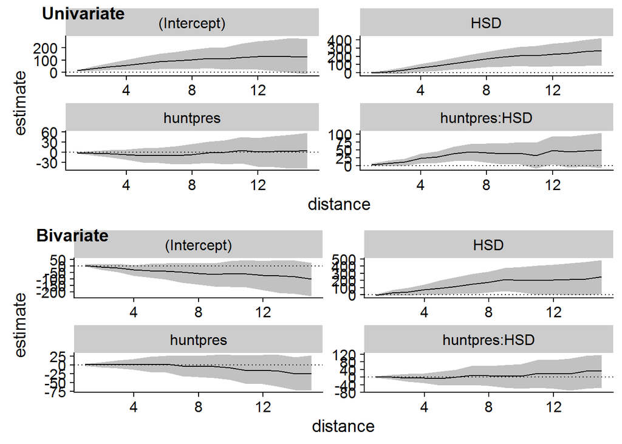

```r
plot_grid(plot(sapMod.uni_ci),
          plot(sapMod.bi_ci),
          labels=c('Univariate', 'Bivariate'), ncol=1)
```

These plots suggest that 1. in the univariate analysis a. within cohort clustering increases with disperser sensitivity b. there is an interaction between huning and HSD so Clustering increases faster with HSD in hunted forests

2. In the bivariate analysis
1. there is more clustering among high HSD species
2. None of the other predictors seem to explain much variation in clustering.

### 2.6 Formal tests of Hypothesis 1

We can use an Anova type analysis

```r
## Get Ns
lme4::getME(sapMod.uni[[1]], "devcomp")$dims[c("N", "q")]
```

```
##   N   q
## 424   6
```

```r
lme4::getME(sapMod.bi[[1]], "devcomp")$dims[c("N", "q")]
```

```
##   N   q
## 308   6
```

```r
## main effects model
sapMod.uni.1way <- klmerHyper(K~huntpres + HSD + (1|site), hyper=hyperdat.uni.sap.c,
                               weights=wts, r=0:rmax, correction="border")


aov.hp_sapuni <- anova(sapMod.uni.1way, term="huntpres", dists=distlist,
                nboot=nsim, ncore=7, iseed=1234)
```

```
## [1] "clusters closed on exit"
```

```r
aov.hsd_sapuni <- anova(sapMod.uni.1way, term="HSD", dists=distlist,
                nboot=nsim, ncore=7, iseed=1234)
```

```
## [1] "clusters closed on exit"
```

```r
aov.hp_hsd_sapuni <- anova(sapMod.uni, term="huntpres:HSD", dists=distlist,
                nboot=nsim, ncore=7, iseed=1234)
```

```
## [1] "clusters closed on exit"
```

```r
sapMod.uni.aov <-  list(hunt=aov.hp_sapuni, HSD=aov.hsd_sapuni, "hunt:HSD" = aov.hp_hsd_sapuni)
save(sapMod.uni.aov, file = "../results/v8.0/aov_sapModuni.RData")

sapMod.bi.1way <- klmerHyper(K~huntpres + HSD + (1|site), hyper=hyperdat.bi.sap.c,
                               weights=wts, r=0:rmax, correction="border")

aov.hp_sapbi <- anova(sapMod.bi.1way, term="huntpres", dists=distlist,
                nboot=nsim, ncore=7, iseed=1234)
```

```
## [1] "clusters closed on exit"
```

```r
aov.hsd_sapbi <- anova(sapMod.bi.1way, term="HSD", dists=distlist,
                nboot=nsim, ncore=7, iseed=1234)
```

```
## [1] "clusters closed on exit"
```

```r
aov.hp_hsd_sapbi <- anova(sapMod.bi, term="huntpres:HSD", dists=distlist,
                nboot=nsim, ncore=7, iseed=1234)
```

```
## [1] "clusters closed on exit"
```

```r
sapMod.bi.aov <-  list(hunt=aov.hp_sapbi, HSD=aov.hsd_sapbi, "hunt:HSD" = aov.hp_hsd_sapbi)
save(sapMod.bi.aov, file = "../results/v8.0/aov_sapModbi.RData")
##load("../results/v8.0/aov_sapModuni.RData")
##load("../results/v8.0/aov_sapModbi.RData")
```

Now let us look at the results

```r
## univariate model
do.call('cbind', lapply(1:4, function(i)
  t(sapply(sapMod.uni.aov, function(x) x$T[[i]]$stat))))
```

|  | T | p | T | p | T | p | T | p |
| --- | --- | --- | --- | --- | --- | --- | --- | --- |
| hunt | 0.388 | 0.624 | 0.026 | 0.985 | 0.451 | 0.532 | 0.686 | 0.429 |
| HSD | 5.598 | 0.010 | 1.759 | 0.164 | 7.537 | 0.006 | 7.498 | 0.007 |
| hunt:HSD | 5.514 | 0.006 | 5.442 | 0.011 | 7.642 | 0.005 | 3.459 | 0.052 |

```r
## Bivariate model
do.call('cbind', lapply(1:4, function(i)
  t(sapply(sapMod.bi.aov, function(x) x$T[[i]]$stat))))
```

|  | T | p | T | p | T | p | T | p |
| --- | --- | --- | --- | --- | --- | --- | --- | --- |
| hunt | 0.168 | 0.948 | 0.072 | 0.983 | 0.094 | 0.887 | 0.339 | 0.607 |
| HSD | 3.813 | 0.020 | 2.950 | 0.063 | 5.229 | 0.021 | 3.260 | 0.063 |
| hunt:HSD | 0.165 | 0.943 | 0.107 | 0.953 | 0.053 | 0.939 | 0.334 | 0.589 |

Prety clear pattern that hunting increases clustering among high HSD saplings.

Additionally, worth checking juveniles on their own (do the patterns persist into larger size-classes)

```r
## Get Ns

## main effects model
juvMod.uni.1way <- klmerHyper(K~huntpres + HSD + (1|site), hyper=hyperdat.uni.juv,
                               weights=wts, r=0:rmax, correction="border")


aov.hp_juvuni <- anova(juvMod.uni.1way, term="huntpres", dists=distlist,
                nboot=nsim, ncore=7, iseed=1234)
```

```
## [1] "clusters closed on exit"
```

```r
aov.hsd_juvuni <- anova(juvMod.uni.1way, term="HSD", dists=distlist,
                nboot=nsim, ncore=7, iseed=1234)
```

```
## [1] "clusters closed on exit"
```

```r
aov.hp_hsd_juvuni <- anova(juvMod.uni, term="huntpres:HSD", dists=distlist,
                nboot=nsim, ncore=7, iseed=1234)
```

```
## [1] "clusters closed on exit"
```

```r
juvMod.uni.aov <-  list(hunt=aov.hp_juvuni, HSD=aov.hsd_juvuni, "hunt:HSD" = aov.hp_hsd_juvuni)

save(juvMod.uni.aov, file = "../results/v8.0/aov_juvModuni.RData")


## main effects model
juvMod.bi.1way <- klmerHyper(K~huntpres + HSD + (1|site), hyper=hyperdat.bi.juv,
                               weights=wts, r=0:rmax, correction="border")


aov.hp_juvbi <- anova(juvMod.bi.1way, term="huntpres", dists=distlist,
                nboot=nsim, ncore=7, iseed=1234)
```

```
## [1] "clusters closed on exit"
```

```r
aov.hsd_juvbi <- anova(juvMod.bi.1way, term="HSD", dists=distlist,
                nboot=nsim, ncore=7, iseed=1234)
```

```
## [1] "clusters closed on exit"
```

```r
aov.hp_hsd_juvbi <- anova(juvMod.bi, term="huntpres:HSD", dists=distlist,
                nboot=nsim, ncore=7, iseed=1234)
```

```
## [1] "clusters closed on exit"
```

```r
juvMod.bi.aov <-  list(hunt=aov.hp_juvbi,
                       HSD=aov.hsd_juvbi,
                       "hunt:HSD" = aov.hp_hsd_juvbi)

## univariate model
do.call('cbind', lapply(1:4, function(i)
  t(sapply(juvMod.uni.aov, function(x) x$T[[i]]$stat))))
```

|  | T | p | T | p | T | p | T | p |
| --- | --- | --- | --- | --- | --- | --- | --- | --- |
| hunt | 1.08 | 0.337 | 0.32 | 0.728 | 1.38 | 0.249 | 1.55 | 0.226 |
| HSD | 5.67 | 0.008 | 2.02 | 0.131 | 6.46 | 0.010 | 8.54 | 0.006 |
| hunt:HSD | 2.91 | 0.055 | 1.68 | 0.170 | 4.64 | 0.024 | 2.40 | 0.102 |

```r
## bivariate model
do.call('cbind', lapply(1:4, function(i)
  t(sapply(juvMod.bi.aov, function(x) x$T[[i]]$stat))))
```

|  | T | p | T | p | T | p | T | p |
| --- | --- | --- | --- | --- | --- | --- | --- | --- |
| hunt | 0.444 | 0.695 | 0.888 | 0.416 | 0.286 | 0.688 | 0.158 | 0.791 |
| HSD | 0.747 | 0.444 | 0.488 | 0.641 | 0.772 | 0.387 | 0.983 | 0.332 |
| hunt:HSD | 0.149 | 0.957 | 0.264 | 0.841 | 0.081 | 0.900 | 0.103 | 0.857 |

## 3 Changes between saplings and juveniles (Hypotheses 2 & 3)

### 3.1 Univariate model

#### 3.1.1 Fit univariate model

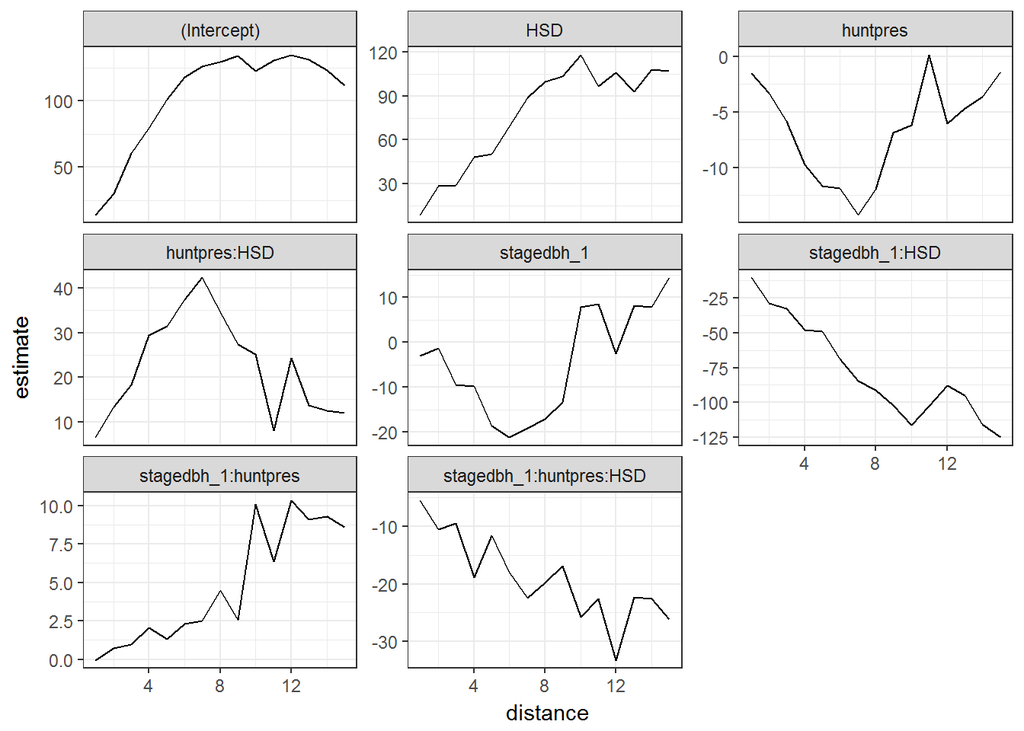

```r
hyperdat.uni.sel.c <- subset(hyperdat.uni.sel.c,
                             !(
                               site == "BM" & sp.id %in% c(736, 724, 562, 569) |
                                 site == "LA" & sp.id == 764 |
                                 site == "RA" & sp.id == 446 |
                                 site == "TRC" & sp.id %in% c(609, 411, 562)
                             ))

## Full model with Juveniles and saplings (pair2)
##hyperdat.uni.sel.c$stage <- factor(hyperdat.uni.sel.c$stage, ordered=FALSE)
intMod.uni <- klmerHyper(K~stage*huntpres*HSD + (1|site/Spp), hyper = hyperdat.uni.sel.c,
                          weights=wts, r=0:rmax, correction="border", na.action="na.omit")

plot(intMod.uni)
```

#### 3.1.2 Model diagnostics

Checking the model diagnostics

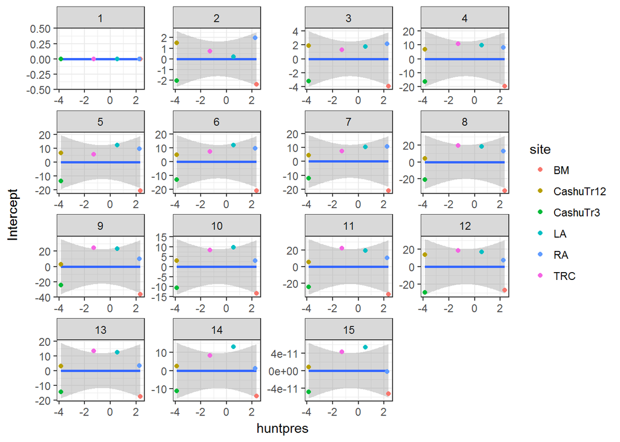

```r
## site level random effects
intMod.uni.ranefs <- extractModRanefs(intMod.uni)
intMod.uni.ranefs <- intMod.uni.ranefs %>% separate(group, into=c('Spp', 'site'),
                                                    sep=":", fill="left")

intMod.uni.ranefs$huntpres <- sitedat$huntpres[match(intMod.uni.ranefs$site,
                                                     sitedat$site)]

subset(intMod.uni.ranefs, level=="site") %>% ggplot(aes(x=huntpres, y=Intercept)) +
  geom_smooth(method='gam', method.args=list(k=5)) + geom_point(aes(col=site)) +
  facet_wrap(~distance, scale='free') + theme_bw()
```

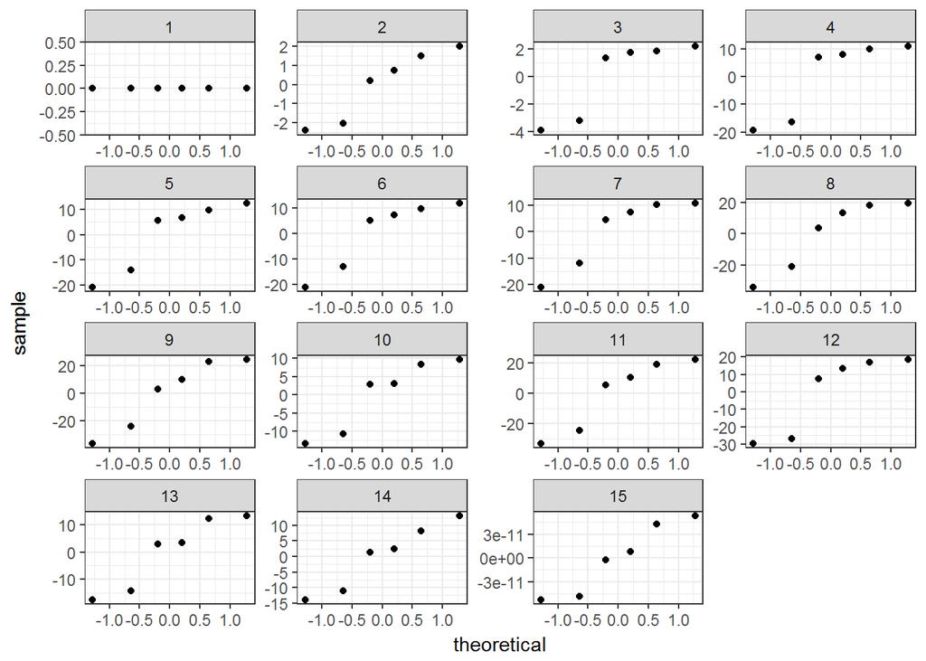

```r
subset(intMod.uni.ranefs, level=="site") %>% ggplot(aes(sample=Intercept)) + geom_qq() +
  facet_wrap(~distance, scale='free') + theme_bw()
```

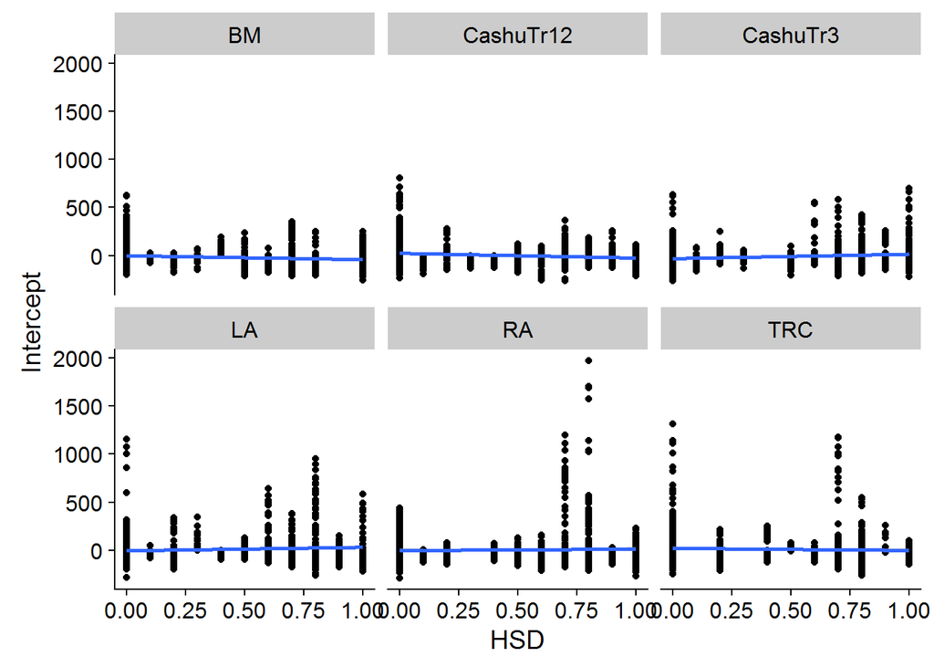

```r
## species level random effects
intMod.uni.ranefs$HSD <- dispersal$HSD[match(intMod.uni.ranefs$Spp, dispersal$Spp)]

subset(intMod.uni.ranefs, level=="Spp:site") %>%
  ggplot(aes(x=HSD, y=Intercept)) + geom_point() +
  geom_smooth(method='gam', method.args=list(k=5)) + facet_wrap(~site)
```

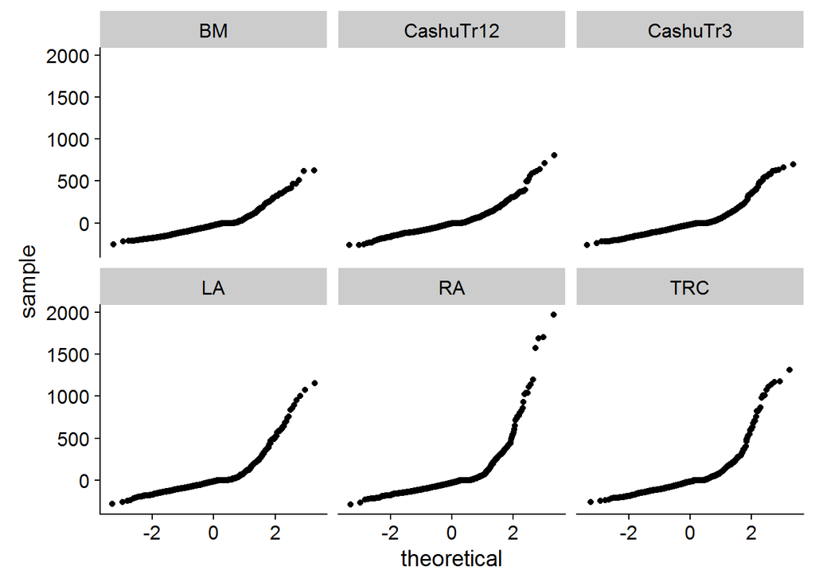

```r
subset(intMod.uni.ranefs, level=="Spp:site") %>%
  ggplot(aes(sample=Intercept)) + geom_qq() + facet_wrap(~site)
```